# Before_Workshop

## SSC 2022 Reproducibility Workshop

### Join our Slack Community

We are using the Statistical Education Section’s Slack as a home for this workshop, and the follow-ups afterward. You can join this Slack [for free](https://join.slack.com/t/sscstatistics-2n57302/shared_invite/zt-roolxsm8-RXc3rjbi~BMyzutPL8UJ9w), and we encourage you to hop on and then join the ses2022workshop-reproducibility channel. Both Tiffany and Wesley will be in the channel before/during/after the workshop.

### Local Installation

Before the workshop, if you want to work on your own computer and your own file system, you should complete the following steps.

1. Update your version of R locally to at least 4.0, preferably [4.2.0](https://cran.r-project.org/).
2. Update your version of RStudio locally to at least 2022.02, to match the flow we will show.
3. Install Git locally ([Windows](https://git-for-windows.github.io/); [Mac](https://www.freecodecamp.org/news/install-xcode-command-line-tools/)).

Regardless of whether you will work locally, or on the provided server environment, you will need to register for a GitHub account (below).

### Server Environment

An account has been created for you on Wesley’s RStudio Workbench/Server, as ses hyphen first initial + last name (e.g., ses-wburr). The password for all accounts has been set to the password provided to you via the contact email. If you login to the provided URL, you will be presented with the RStudio interface, and you can create a new project or configure your interface as we will discuss during the workshop.

### Either Way …

4. Register for a GitHub account. This is intended as a **professional** account, so consider [reading this guide](https://happygitwithr.com/github-acct.html) to help with account name selection and details on account types.

[figure not shown]

GitHub signup

5. Set up a SSH public/private key pair. Keys provide a more secure way of communicating / connecting across the internet than using passwords, and are **required** for GitHub use.

Because this key creation can vary so much across different platforms, we suggest you use RStudio’s built-in utility to do it. Go to Tools > Global Options…> Git/SVN > Create RSA Key.

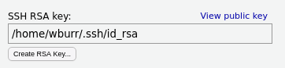

RStudio Create RSA Key

RStudio prompts you for a passphrase: if you’re completely new at all this, skip the passphrase. Click “Create”” and RStudio will generate an SSH key pair, stored in the files ~/.ssh/id_rsa and ~/.ssh/id_rsa.pub. The ~ is a “home” directory, which varies by architecture, but is universal and can simply be used.

Then, RStudio should have an option in that same screen (under Git/SVN), to “View Public Key”. Do that, and accept the offer to copy to your clipboard.

Go back to GitHub, where you created your account. Click on your profile pic in upper right corner and go to Settings > SSH and GPG keys. Click “New SSH key”. Paste your public key in the “Key” box. Set a title, then click “Add SSH key”. This will let your computer (or account on the server) communicate seamlessly with GitHub, and will be necessary for each account you want to use on each computer.

## And Now You’re Ready

You’ve updated RStudio and R (or are using the server), have a GitHub account and SSH key, and you’re ready for us to help you set up the later stages.

If you want to check to see that everything is installed, try this:

1. In RStudio, click File > New Project. Do you see an option to create from Version Control? If yes, good.
2. Select New Directory > Empty Project. Do you see a checkbox “Create a git repository”? If yes, good, CHECK IT.

If these aren’t correct, please feel free to reach out for help!